# Practical Machine Learning Course Project

Monica Bhat

June 12, 2016

These is a project submitted during a homework assignment of Coursera’s MOOC **Practical Machine Learning** from **Johns Hopkins Bloomberg School of Public Health**.

## Background

Using devices such as Jawbone Up, Nike FuelBand, and Fitbit, it is now possible to collect a large amount of data about personal activity relatively inexpensively. These type of devices are part of the quantified self movement – a group of enthusiasts who take measurements about themselves regularly to improve their health, to find patterns in their behavior, or because they are tech geeks. One thing that people regularly do is quantify how much of a particular activity they do, but they rarely quantify how well they do it. In this project, our goal is to use data from accelerometers on the belt, forearm, arm, and dumbell of 6 participants. They were asked to perform barbell lifts correctly and incorrectly in 5 different ways. More information is available from the website here: [http://groupware.les.inf.puc-rio.br/har].

## Data

The training data for this project are available here:

[https://d396qusza40orc.cloudfront.net/predmachlearn/pml-training.csv]

The test data are available here:

[https://d396qusza40orc.cloudfront.net/predmachlearn/pml-testing.csv]

The data for this project come from this source: [http://groupware.les.inf.puc-rio.br/har].

## Replicating Results of this Experiment

Please install packages listed below and use the same seed, To install, for instance, the `caret` package in R, run this command: `install.packages("caret")`.  
To avoid reinstall, run the following command: `if("caret" %in% rownames(installed.packages()) == FALSE) {install.packages("caret")} ;`

The following Libraries were used in this project, and should be loaded in working environment.

```r
library(rattle)
library(caret)
```

```r
library(rpart)
library(rpart.plot)
library(corrplot)
library(randomForest)
library(RColorBrewer)
```

## Set Seed

Load the same seed with the following line of code:

```r
set.seed(12345)
```

## Load Data

Read the datafiles from URL provided in project statement and load the dataframes for training and testing datasets.

```r
trainLocation <-"https://d396qusza40orc.cloudfront.net/predmachlearn/pml-training.csv"
testLocation <- "https://d396qusza40orc.cloudfront.net/predmachlearn/pml-testing.csv"
trainingData <- read.csv(url(trainLocation), na.strings=c("NA","#DIV/0!",""))
testingData <- read.csv(url(testLocation), na.strings=c("NA","#DIV/0!",""))
```

## Data Cleaning Steps

Clean the dataset and get rid of observations with missing values as well as redundant variables.

```r
NZV <- nearZeroVar(trainingData, saveMetrics = TRUE)
head(NZV, 20)
```

```
##                      freqRatio percentUnique zeroVar   nzv
## X                     1.000000  100.00000000   FALSE FALSE
## user_name             1.100679    0.03057792   FALSE FALSE
## raw_timestamp_part_1  1.000000    4.26562022   FALSE FALSE
## raw_timestamp_part_2  1.000000   85.53154622   FALSE FALSE
## cvtd_timestamp        1.000668    0.10192641   FALSE FALSE
## new_window           47.330049    0.01019264   FALSE  TRUE
## num_window            1.000000    4.37264295   FALSE FALSE
## roll_belt             1.101904    6.77810621   FALSE FALSE
## pitch_belt            1.036082    9.37722964   FALSE FALSE
## yaw_belt              1.058480    9.97349913   FALSE FALSE
## total_accel_belt      1.063160    0.14779329   FALSE FALSE
## kurtosis_roll_belt    2.000000    2.01304658   FALSE FALSE
## kurtosis_picth_belt   1.333333    1.60534094   FALSE FALSE
## kurtosis_yaw_belt     0.000000    0.00000000    TRUE  TRUE
## skewness_roll_belt    2.000000    2.00285394   FALSE FALSE
## skewness_roll_belt.1  1.333333    1.71236367   FALSE FALSE
## skewness_yaw_belt     0.000000    0.00000000    TRUE  TRUE
## max_roll_belt         1.000000    0.99378249   FALSE FALSE
## max_picth_belt        1.538462    0.11211905   FALSE FALSE
## max_yaw_belt          1.034483    0.33635715   FALSE FALSE
```

```r
trainingClean <- trainingData[, !NZV$nzv]
testingClean <- testingData[, !NZV$nzv]
dim(trainingClean)
```

```
## [1] 19622   124
```

```r
dim(testingClean)
```

```
## [1]  20 124
```

```r
unwanted_col <- grepl("^X|timestamp|user_name", names(trainingClean))
training <- trainingClean[, !unwanted_col]
testing <- testingClean[, !unwanted_col]

dim(training)
```

```
## [1] 19622   119
```

```r
dim(testing)
```

```
## [1]  20 119
```

```r
training <- training[, colSums(is.na(training)) == 0]
testing <- testing[, colSums(is.na(training)) == 0]
```

## Garbage Collection

```r
rm(trainingData)
rm(testingData)
rm(trainingClean)
rm(testingClean)
```

### Correlation Matrix of features in the Training Data.

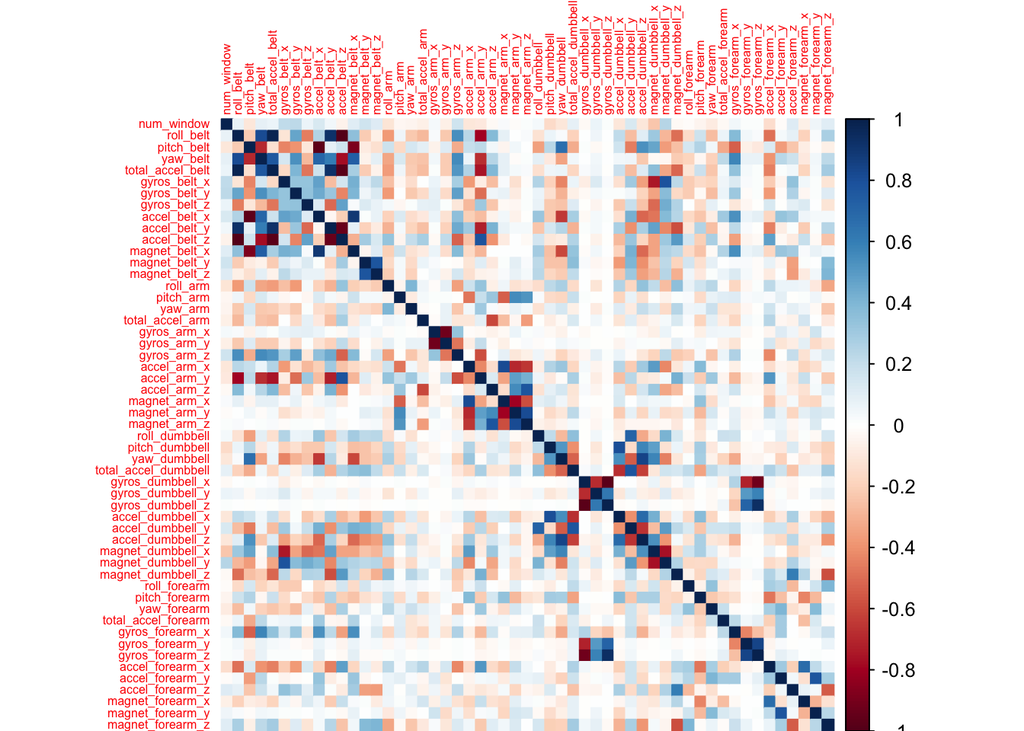

```r
corrplot(cor(training[, -length(names(training))]), method = "color", tl.cex = 0.5)
```

## Data Partitioning

Split the training set into a training data set (70%) and a validation data set (30%). Validation data set is used to conduct cross validation.

```r
set.seed(12345)
inTrain <- createDataPartition(training$classe, p = 0.70, list = FALSE)
validation <- training[-inTrain, ]
training <- training[inTrain, ]
```

## Data Modelling

### Decision Tree Algorithm

Use Decision Tree algorithm for predictive modeling.

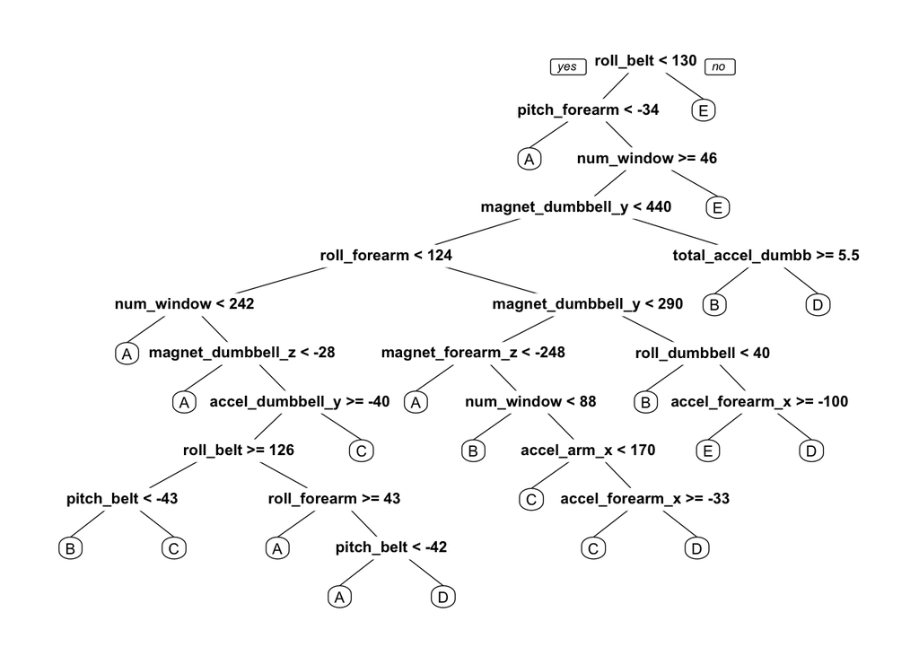

```r
modelTree <- rpart(classe ~ ., data = training, method = "class")
prp(modelTree)
```

```r
predictTree <- predict(modelTree, validation, type = "class")
confusionMatrix(validation$classe, predictTree)
```

```
## Confusion Matrix and Statistics
##
##           Reference
## Prediction    A    B    C    D    E
##          A 1530   35   17   39   53
##          B  269  575   73  146   76
##          C   51   31  743  130   71
##          D   79   25   68  702   90
##          E   16   68   84  128  786
##
## Overall Statistics
##
##                Accuracy : 0.7368
##                  95% CI : (0.7253, 0.748)
##     No Information Rate : 0.3305
##     P-Value [Acc > NIR] : < 2.2e-16
##
##                   Kappa : 0.6656
##  Mcnemar's Test P-Value : < 2.2e-16
##
## Statistics by Class:
##
##                      Class: A Class: B Class: C Class: D Class: E
## Sensitivity            0.7866  0.78338   0.7543   0.6131   0.7305
## Specificity            0.9635  0.89051   0.9422   0.9447   0.9384
## Pos Pred Value         0.9140  0.50483   0.7242   0.7282   0.7264
## Neg Pred Value         0.9014  0.96650   0.9502   0.9100   0.9396
## Prevalence             0.3305  0.12472   0.1674   0.1946   0.1828
## Detection Rate         0.2600  0.09771   0.1263   0.1193   0.1336
## Detection Prevalence   0.2845  0.19354   0.1743   0.1638   0.1839
## Balanced Accuracy      0.8750  0.83694   0.8483   0.7789   0.8345
```

```r
accuracy <- postResample(predictTree, validation$classe)
ose <- 1 - as.numeric(confusionMatrix(validation$classe, predictTree)$overall[1])
```

The Estimated Accuracy of the Decision Tree Algorithm is 73.6788445% and the Estimated Out-of-Sample Error is 26.3211555%.

### Random Forest

Use Random Forest for a predictive model since it automatically selects key variables and is robust to correlated covariates & outliers in general.

```r
modelRF <- randomForest(classe ~. , data=training)
modelRF
```

```
##
## Call:
##  randomForest(formula = classe ~ ., data = training)
##                Type of random forest: classification
##                      Number of trees: 500
## No. of variables tried at each split: 7
##
##         OOB estimate of  error rate: 0.3%
## Confusion matrix:
##      A    B    C    D    E  class.error
## A 3904    1    0    0    1 0.0005120328
## B    5 2650    3    0    0 0.0030097818
## C    0    9 2385    2    0 0.0045909850
## D    0    0   13 2238    1 0.0062166963
## E    0    0    0    6 2519 0.0023762376
```

```r
predictRF <- predict(modelRF, validation)
confusionMatrix(validation$classe, predictRF)
```

```
## Confusion Matrix and Statistics
##
##           Reference
## Prediction    A    B    C    D    E
##          A 1674    0    0    0    0
##          B    5 1133    1    0    0
##          C    0    8 1018    0    0
##          D    0    0   12  952    0
##          E    0    0    0    4 1078
##
## Overall Statistics
##
##                Accuracy : 0.9949
##                  95% CI : (0.9927, 0.9966)
##     No Information Rate : 0.2853
##     P-Value [Acc > NIR] : < 2.2e-16
##
##                   Kappa : 0.9936
##  Mcnemar's Test P-Value : NA
##
## Statistics by Class:
##
##                      Class: A Class: B Class: C Class: D Class: E
## Sensitivity            0.9970   0.9930   0.9874   0.9958   1.0000
## Specificity            1.0000   0.9987   0.9984   0.9976   0.9992
## Pos Pred Value         1.0000   0.9947   0.9922   0.9876   0.9963
## Neg Pred Value         0.9988   0.9983   0.9973   0.9992   1.0000
## Prevalence             0.2853   0.1939   0.1752   0.1624   0.1832
## Detection Rate         0.2845   0.1925   0.1730   0.1618   0.1832
## Detection Prevalence   0.2845   0.1935   0.1743   0.1638   0.1839
## Balanced Accuracy      0.9985   0.9959   0.9929   0.9967   0.9996
```

```r
accuracy <- postResample(predictRF, validation$classe)
ose <- 1 - as.numeric(confusionMatrix(validation$classe, predictRF)$overall[1])
predict(modelRF, testing[, -length(names(testing))])
```

```
##  1  2  3  4  5  6  7  8  9 10 11 12 13 14 15 16 17 18 19 20
##  B  A  B  A  A  E  D  B  A  A  B  C  B  A  E  E  A  B  B  B
## Levels: A B C D E
```

The Estimated Accuracy of the Random Forest Algorithm is 99.4902294% and the Estimated Out-of-Sample Error is 0.5097706%. The Random forest accuracy is much better than decision tree as expected.

## Predicting Test Data Set Results

Now, we apply the Random Forest model to the testing data set downloaded from the project locations.

```r
predict(modelRF, testing[, -length(names(testing))])
```

```
##  1  2  3  4  5  6  7  8  9 10 11 12 13 14 15 16 17 18 19 20
##  B  A  B  A  A  E  D  B  A  A  B  C  B  A  E  E  A  B  B  B
## Levels: A B C D E
```

## Generating Files for Assignment Submission

Function to generate files with predictions to submit for assignment.

```r
pml_write_files = function(x){
  n = length(x)
  for(i in 1:n){
    filename = paste0("problem_id_",i,".txt")
    write.table(x[i], file = filename, quote = FALSE, row.names = FALSE, col.names = FALSE)
  }
}
```

Generating the Files.

```r
pml_write_files(predict(modelRF, testing[, -length(names(testing))]))
```